# K-Nearest Neighbor - Predicting Bug Covering by Ranking

Christian Medeiros Adriano

August 6, 2017

## The goal of the study

Making sense of multiple answers to one same question is challenging if one needs to extract some kind of consensus. The challenges relate to the different levels of skill, but also personal preferences.

In the case of my experiment, I asked workers if they believed that a code fragment was related to a unit test failure. Each question was asked to 20 different workers. Workers answered YES, NO, or I don´t know.

After receiving all the answers for each code fragments, I was left with the challenge of using these answers to predict the code fragments that are most probability related to the failure. I labeled as “bug covering” the questions that were about code fragments that turned out to be related to the unit test failure.

Whe study has two goals:

Train a machine learning algorithm that predicts whether a code fragment is related to a failure or not. For that, I originally devised different metrics. The metric that will explore in the following study consists of ranking the questions by the number of YES answers received. Questions that received the most number of YES answers are assigned ranking level 1.

Compared CLASS and CARET implementations of k-nearest neighbor algorithm. Results showed that CLASS implementation produced fewer false positives than CARET. Note that this might result of overfitting of my use of CLASS configuration of knn.cv.

## Data preparation

I need to guarantee that some examples (i.e., failing methods) do not dominate the training or testing sets. To do that, I need to get a close to equal proportion of examples in both sets. I do that by scrambling the data.

```r
set.seed(9850);
g<- runif((nrow(summaryTable))); #generates a random distribution
summaryTable <- summaryTable[order(g),];#reorder the rows based on a random index

#convert columns to numeric
summaryTable[,"rankingVote"] <- as.numeric(unlist(summaryTable[,"rankingVote"]));

#Select only the ranking as a feature to predict bugCovering
trainingData <- summaryTable[,c("bugCovering","rankingVote")];
trainingData$rankingVote <- as.numeric(trainingData$rankingVote);
```

## KNN from CLASS package

I chose knn.cv (cross validation) so I can minimize the risk of lucky selection of training and testing set.

Cross validations is performed by leaving one out, however even when I set partition to 70/30 I obtained the same reaults.

I also run with differnt levels of k=3,5,7,9, which produced the same results as well

```r
#build model
fitModel.cv <- knn.cv(trainingData, trainingData$bugCovering, k=3, l=0, prob = FALSE, use.all=TRUE);
```

## Testing the model

```r
fitModel.cv.df<-data.frame(fitModel.cv);
CrossTable(x = trainingData$bugCovering, y=fitModel.cv.df[,1], prop.chisq = FALSE)
```

```
##
##
##    Cell Contents
## |-------------------------|
## |                       N |
## |           N / Row Total |
## |           N / Col Total |
## |         N / Table Total |
## |-------------------------|
##
##
## Total Observations in Table:  129
##
##
##                          | fitModel.cv.df[, 1]
## trainingData$bugCovering |     FALSE |      TRUE | Row Total |
## -------------------------|-----------|-----------|-----------|
##                    FALSE |       102 |         2 |       104 |
##                          |     0.981 |     0.019 |     0.806 |
##                          |     0.944 |     0.095 |           |
##                          |     0.791 |     0.016 |           |
## -------------------------|-----------|-----------|-----------|
##                     TRUE |         6 |        19 |        25 |
##                          |     0.240 |     0.760 |     0.194 |
##                          |     0.056 |     0.905 |           |
##                          |     0.047 |     0.147 |           |
## -------------------------|-----------|-----------|-----------|
##             Column Total |       108 |        21 |       129 |
##                          |     0.837 |     0.163 |           |
## -------------------------|-----------|-----------|-----------|
##
##
```

## Estimating the metric

Discover the minimal ranking value that would have predicted the same bug Covering questions

Mean ranking vote of the questions categorized as bug covering:

```
## [1] 1.714286
```

Top ranking vote of the questions categorized as bug covering:

```
## [1] 1
```

Lowest ranking vote of the questions still categorized as bug covering:

```
## [1] 3
```

## Plot metric distribution

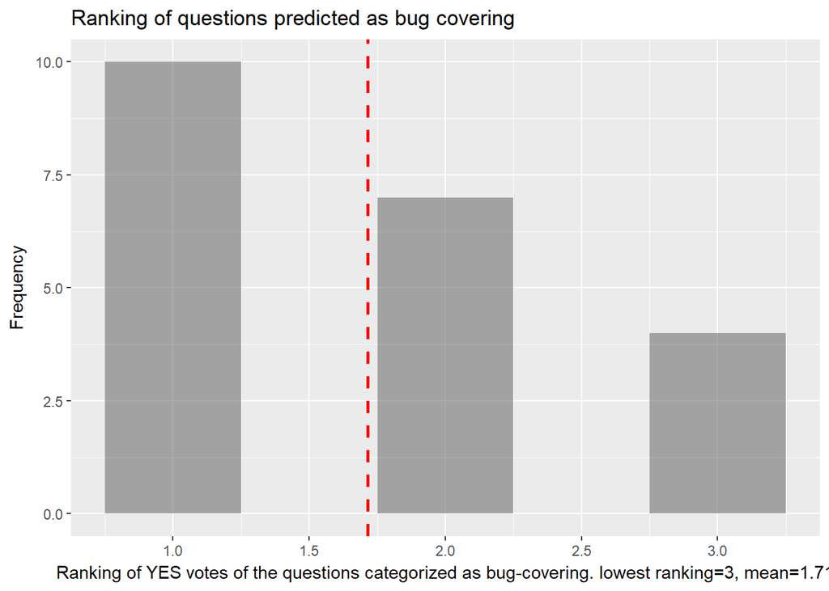

```r
predictedList.df <- data.frame(predictedList);
colnames(predictedList.df)<- c("votes");

ggplot(data=predictedList.df, aes(x=predictedList.df$votes)) +
  geom_histogram(binwidth = 0.5,alpha=.5, position="identity")+
  geom_vline(aes(xintercept=mean(predictedList.df$votes, na.rm=T)),   # Ignore NA values for mean
             color="red", linetype="dashed", size=1) +
  ggtitle("Ranking of questions predicted as bug covering")+
  labs(x="Ranking of YES votes of the questions categorized as bug-covering. lowest ranking=3, mean=1.71",
       y="Frequency");
```

## Why not use k=1?

For a more detailed discussion on k=1 value, refer to https://stats.stackexchange.com/questions/107870/does-k-nn-with-k-1-always-implies-overfitting#107913

## KNN from CARET package

https://cran.r-project.org/web/packages/caret/vignettes/caret.pdf

https://dataaspirant.com/2017/01/09/knn-implementation-r-using-caret-package/

I will do 5 repeats of 10-Fold CV. I will fit a KNN model that evaluates 10 values of k

```
## [1] 5.248062
```

### Model selection

```r
knn_fit
```

```
## k-Nearest Neighbors
##
## 129 samples
##   1 predictor
##   2 classes: 'FALSE', 'TRUE'
##
## Pre-processing: centered (1), scaled (1)
## Resampling: Cross-Validated (10 fold, repeated 5 times)
## Summary of sample sizes: 116, 117, 116, 116, 116, 115, ...
## Resampling results across tuning parameters:
##
##   k   Accuracy   Kappa
##    5  0.8731685  0.5275465
##    7  0.8717399  0.5196293
##    9  0.8760256  0.5339682
##   11  0.8774359  0.5200817
##   13  0.8760256  0.5382455
##   15  0.8760256  0.5382455
##   17  0.8760256  0.5382455
##   19  0.8760256  0.5382455
##   21  0.8760256  0.5382455
##   23  0.8760256  0.5382455
##
## Accuracy was used to select the optimal model using  the largest value.
## The final value used for the model was k = 11.
```

#### Confusion matrix using the selected model

```r
bugCoveringPredicted <- predict(knn_fit,newdata = trainingData);

confusionMatrix(data=bugCoveringPredicted,trainingData$bugCovering, mode="prec_recall", positive="TRUE")
```

```
## Confusion Matrix and Statistics
##
##           Reference
## Prediction FALSE TRUE
##      FALSE    98   10
##      TRUE      6   15
##
##                Accuracy : 0.876
##                  95% CI : (0.8064, 0.9274)
##     No Information Rate : 0.8062
##     P-Value [Acc > NIR] : 0.02467
##
##                   Kappa : 0.5774
##  Mcnemar's Test P-Value : 0.45325
##
##               Precision : 0.7143
##                  Recall : 0.6000
##                      F1 : 0.6522
##              Prevalence : 0.1938
##          Detection Rate : 0.1163
##    Detection Prevalence : 0.1628
##       Balanced Accuracy : 0.7712
##
##        'Positive' Class : TRUE
##
```

Compute the minimal ranking value that corresponded to the predicted bugCovering questions

```
## [1] 1.52381
```

```
## [1] 2
```

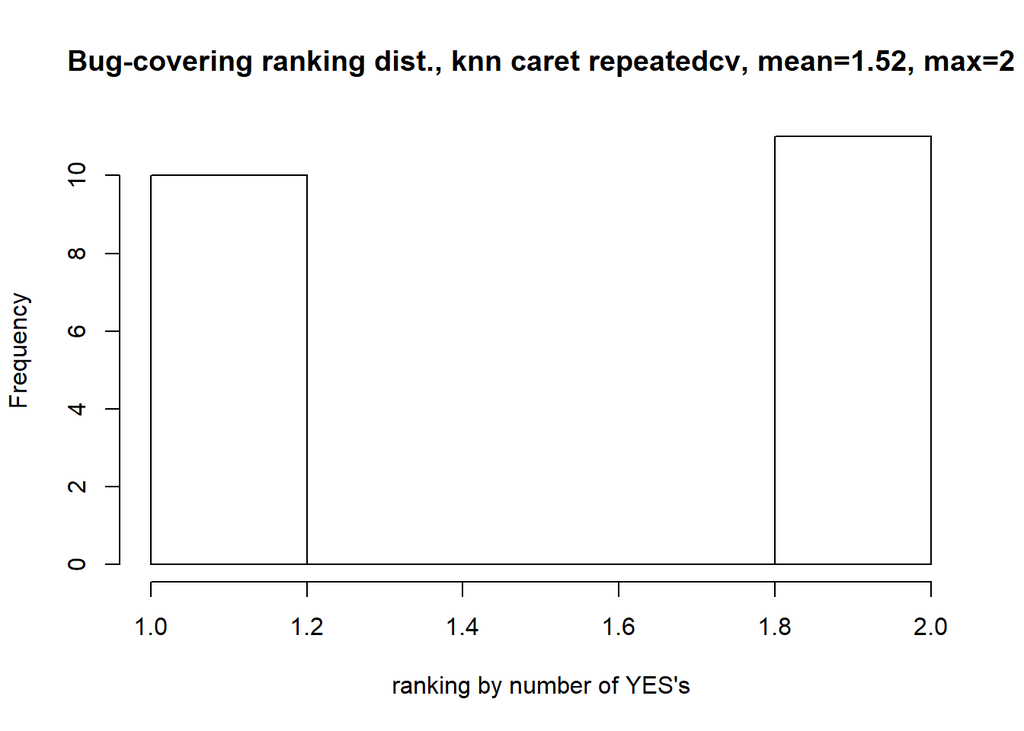